# Power calculation for COVID-19 and air pollution study

Sergio Olmos

August 2020

Statistical power was assessed using the closed-form formula derived by Hsieh and Lavori (2000)[^1] for the Cox PH model as implemented in the `powerSurvEpi` R package[^2].

The calculations assume the following Cox PH model:

$h(t | x_1, \boldsymbol{x}_2) = h_0(t) \exp(\beta_1 x_1 + \boldsymbol{\beta}_2 \boldsymbol{x}_2)$

where the covariate $X_1$ represents PM2.5 exposure and $\boldsymbol{X}_2$ is a vector of other covariates.

Given the type I error rate $\alpha$ for a two-sided test, the power required to detect a hazard ratio as small as $\exp(\beta_1) = \theta$ is

$power = \phi \left(-z_{1-\alpha/2} + \sqrt{n[\log(\theta)^2] \sigma^2 \psi (1 - \rho^2)}\right)$

where $\sigma^2 = Var(X_1)$, $\psi$ is the proportion of events of interest, and $\rho$ is the multiple correlation coefficient of the following linear regression:

$x_1 = b_0 + \boldsymbol{b}^T \boldsymbol{x}_2.$

Incidence was obtained from Generalitat de Catalunya[^3] and Ministerio de Sanidad[^4].

## Exposure

The air pollution exposures used in the power calculations are derived from APACHE model estimates linked to over 3 million people in Cataluña from PADRIS.

For long-term exposure we used the variance in PM2.5 annual exposures for all 3 million individuals.

For short-term exposure, daily measurements from Vall d'Hebron station from 2014 to 2018 were used to estimate PM2.5 exposures variance. The estimated day-to-day variance is much larger than the spatial variance at any given time point as expected.

## Aim 1

Test whether long-term exposure to air pollution is associated with COVID-19 hospital admissions or mortality in the general population.

### Incidence

- Population size: ~5,000,000
- Number of COVID-19 cases that needed hospitalization: ~32,000
- Number of COVID-19 related deaths: ~13,000

### Exposure

For long-term exposure, the variance in PM2.5 exposure is taken to be the variance in average annual PM2.5 exposure for each individual, as estimated by APACHE:

- Variance: 3.98

### Power

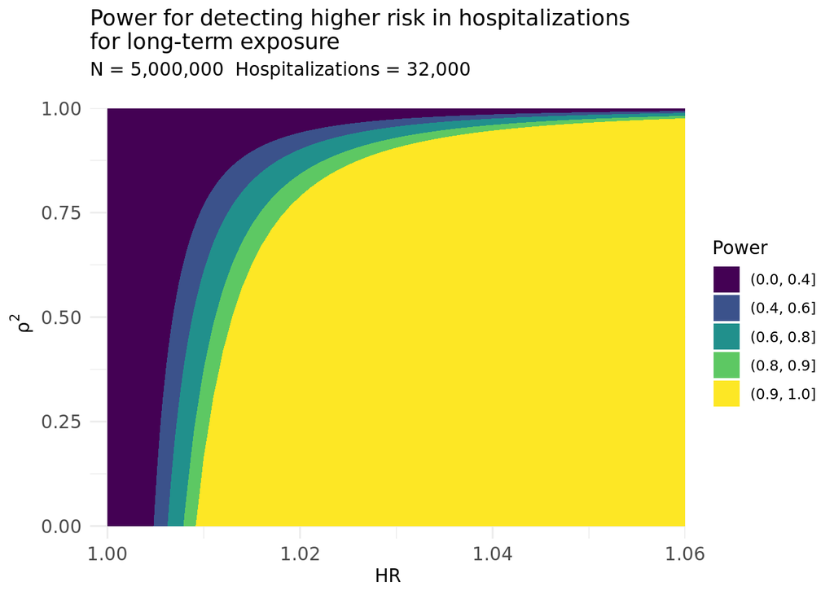

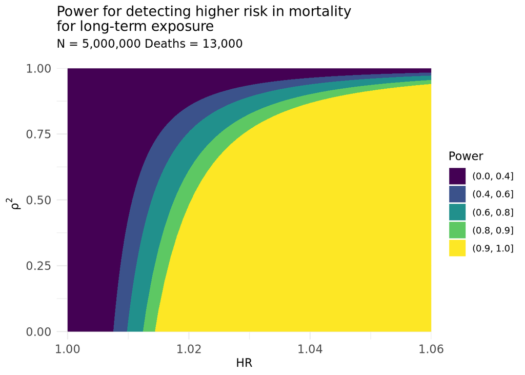

## Aim 2

Test whether short-term exposure to air pollution is associated with COVID-19 hospital admissions or mortality in the general population.

### Incidence

- Number of COVID-19 diagnosed subjects: ~115,000
- Number of COVID-19 cases that needed hospitalizations: ~32,000
- Number of COVID-19 related deaths: ~13,000

### Exposure

For short-term exposure, PM2.5 exposure variance is taken to be the average variance in daily PM2.5 concentration measurements from Vall d'Hebron station among all recorded months:

- Variance: 19.26

### Power

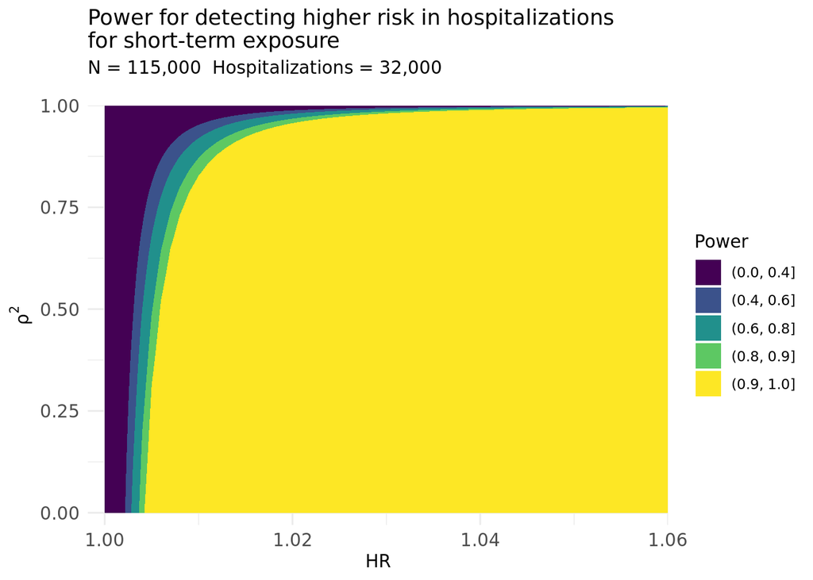

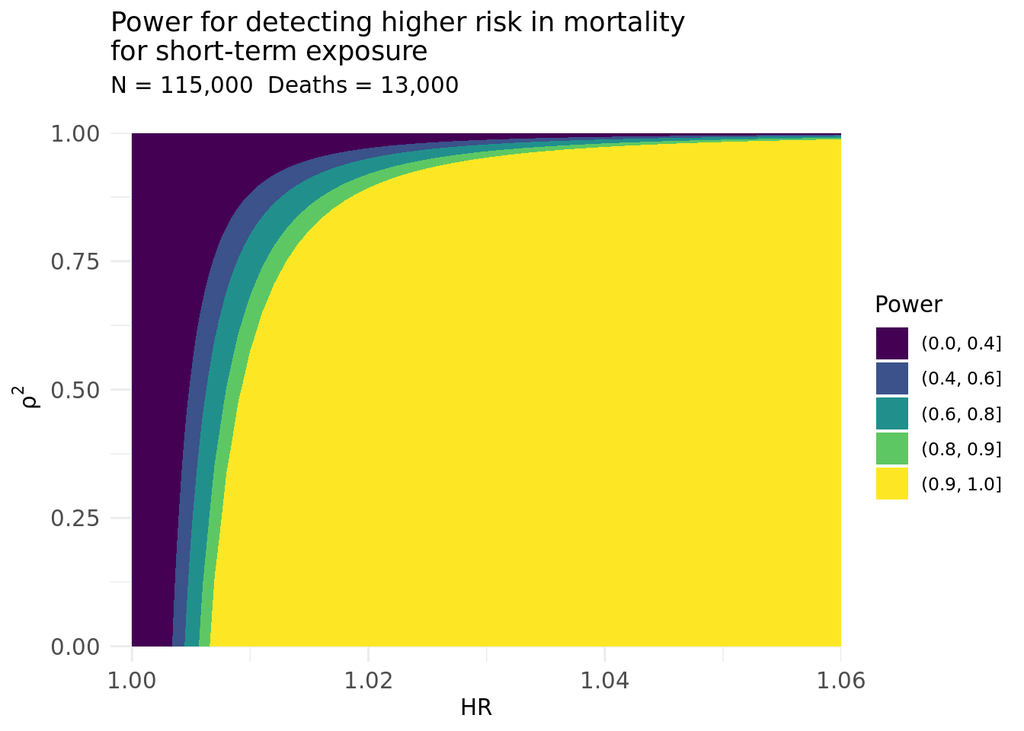

## References

[^1]: Hsieh F.Y. and Lavori P.W. (2000). Sample-size calculation for the Cox proportional hazards regression model with nonbinary covariates. Controlled Clinical Trials. 21:552-560.
[^2]: powerSurvEpi: Power and Sample Size Calculation for Survival Analysis of Epidemiological Studies. (https://cran.r-project.org/web/packages/powerSurvEpi/index.html)
[^3]: https://dadescovid.cat/
[^4]: https://github.com/victorvicpal/COVID19_es/blob/master/data/pdf_data/Actualizacion_90_COVID-19.pdf